# Coursera Course 8 Week 4 - Prediction Assignment

Areddyus  
July 19, 2017

## Excutive Summary

A prediction model was successfully arrived at for weather or not a person was doing an activity correctly, as compared to just predicting how much of the activity they were doing. The accuracy of the model was above 99% and had a slightly larger error rate when used on unseen data than the error rate when used on sample data with known outcomes suggeting model was not overfitted.

## Overview

The objective of this analysis was to come up with a predictive model to determine weather or not a person was doing an activity correctly not just how much of the activity they were doing. The dataset comes from data captured using wearable devices such as Jawbone Up, Nike FuelBand, and Fitbit. Accelerometers on the belt, forearm, arm, and dumbell of 6 participants captured data while they performed barbell lifts correctly and incorrectly in 5 different ways. More information is available from the website http://groupware.les.inf.puc-rio.br/har under the section entitled “Weight Lifting Exercises Dataset”.

## Data Processing

Here I’ll load the data and do some data tidying in order to make creation of predictive model feasible. When it comes to dropping columns deemed unnecessary or with too many missing values I’ll only be doing this on training dataset as prediction model won’t care they are present when run against testing dataset as it’ll only use column data determined to be relevant.

```r
trainingUrl <- "https://d396qusza40orc.cloudfront.net/predmachlearn/pml-training.csv"
testingUrl <- "https://d396qusza40orc.cloudfront.net/predmachlearn/pml-testing.csv"
training <- read.csv(trainingUrl, na.strings=c("", "#DIV/0!", "NA"))
testing <- read.csv(testingUrl, na.strings = c("", "#DIV/0!", "NA"))
```

First i’ll remove columns from data that shouldn’t be relevant to activity quality predictive model.

```r
# the first column of the data is just a row number, perhaps from write.cvs w/o row.names = FALSE
training$X <- NULL
# the user name and timestamp of activities should have no effect on whether they were done correctly
for (col in c("user_name", "raw_timestamp_part_1", "raw_timestamp_part_2", "cvtd_timestamp")) {
    training[,col] <- NULL
}
```

Second i’ll remove columns from data that have significant number of missing values and ones that have so little, or no, variance such that they are irrelevant predictors.

```r
colSumNAs <- apply(training, 2, function(x) sum(is.na(x)))
training <- training[, colSumNAs == 0] # drop all NAs or < some threshold
#training <- training[, colSums(is.na(training)) < 100] # drop all NAs or < some threshold

library(caret); nsv <- nearZeroVar(training); training <- training[-nsv] # drop zero variance predictors
# training <- training[, !sapply(training, is.character)] # drop character class columns which zvp covers
```

```r
colnames(training)
```

```
FALSE  [1] "num_window"           "roll_belt"            "pitch_belt"
FALSE  [4] "yaw_belt"             "total_accel_belt"     "gyros_belt_x"
FALSE  [7] "gyros_belt_y"         "gyros_belt_z"         "accel_belt_x"
FALSE [10] "accel_belt_y"         "accel_belt_z"         "magnet_belt_x"
FALSE [13] "magnet_belt_y"        "magnet_belt_z"        "roll_arm"
FALSE [16] "pitch_arm"            "yaw_arm"              "total_accel_arm"
FALSE [19] "gyros_arm_x"          "gyros_arm_y"          "gyros_arm_z"
FALSE [22] "accel_arm_x"          "accel_arm_y"          "accel_arm_z"
FALSE [25] "magnet_arm_x"         "magnet_arm_y"         "magnet_arm_z"
FALSE [28] "roll_dumbbell"        "pitch_dumbbell"       "yaw_dumbbell"
FALSE [31] "total_accel_dumbbell" "gyros_dumbbell_x"     "gyros_dumbbell_y"
FALSE [34] "gyros_dumbbell_z"     "accel_dumbbell_x"     "accel_dumbbell_y"
FALSE [37] "accel_dumbbell_z"     "magnet_dumbbell_x"    "magnet_dumbbell_y"
FALSE [40] "magnet_dumbbell_z"    "roll_forearm"         "pitch_forearm"
FALSE [43] "yaw_forearm"          "total_accel_forearm"  "gyros_forearm_x"
FALSE [46] "gyros_forearm_y"      "gyros_forearm_z"      "accel_forearm_x"
FALSE [49] "accel_forearm_y"      "accel_forearm_z"      "magnet_forearm_x"
FALSE [52] "magnet_forearm_y"     "magnet_forearm_z"     "classe"
```

## Data Analysis

Now I’m going to build a random forest model to enable predicting the classe outcome. To determine the accuracy of the model I’ll use a cross-validation approach involving 10-fold random subsampling, vs k-fold or leave one out, approach. Within each fold an 80/20 split of train and test data will be created. Note that documentation on random forest training function suggests that caller need not orchestrate cross-validation, see appendix referenced article for more details. Even so i included cross-validation given assignment details and discussions suggested that reviewers would be expecting to see it done vs relying on capabilities of classification function.

```r
library(randomForest); set.seed(100); obs <- c(); preds <- c()
for (i in 1:10) { # takes approximately 8 minutes to run w/o cluster
    inTrain <- sample(1:dim(training)[1], size = dim(training)[1] * 0.8, replace = FALSE)
    trainingCv <- training[inTrain,]; testingCv <- training[-inTrain,]
    modelRf <- randomForest(classe ~ ., data = trainingCv)
    obs <- c(obs, testingCv$classe); preds <- c(preds, predict(modelRf, testingCv))
}
```

The confusion matrix for predictions arrived at uing using cross-validation training and test data is as follows.

```r
confmat <- confusionMatrix(table(preds, obs))
confmat$table; confmat$overall[["Accuracy"]]
```

```
FALSE      obs
FALSE preds     1     2     3     4     5
FALSE     1 11086    12     0     0     0
FALSE     2     1  7706    21     0     0
FALSE     3     0     4  6795    27     0
FALSE     4     0     0     0  6430    10
FALSE     5     0     0     0     1  7157
```

```
FALSE [1] 0.9980637
```

We see in the contingency table only a few misclassifications and an overall accuracy of 99.81%. This suggests the random forest model is doing a good enough job at classifying. I’ll now proceed to apply it to the entire training dataset to arrive at model that can be used predict the classe outcome given the accelerometer captured prediction data.

```r
set.seed(100)
modelRf <- randomForest(classe ~ ., data = training) # takes approximately a minute to run w/o cluster
modelRf # $finalModel necessary to access details if using train() vs randomForest()
```

```
FALSE
FALSE Call:
FALSE  randomForest(formula = classe ~ ., data = training)
FALSE                Type of random forest: classification
FALSE                      Number of trees: 500
FALSE No. of variables tried at each split: 7
FALSE
FALSE         OOB estimate of  error rate: 0.14%
FALSE Confusion matrix:
FALSE      A    B    C    D    E  class.error
FALSE A 5579    1    0    0    0 0.0001792115
FALSE B    3 3793    1    0    0 0.0010534633
FALSE C    0    6 3416    0    0 0.0017533606
FALSE D    0    0   13 3202    1 0.0043532338
FALSE E    0    0    0    3 3604 0.0008317161
```

```r
#rownames(modelRf$importance)[order(modelRf$importance, decreasing = TRUE)] # to see list of predictors by importance
#oobEer <- sum(modelRf$err.rate[, 1])/nrow(modelRf$err.rate) # todo: how to acquire modelRf "oob estimate of error rate"
cvPredictionsAccuracy <- confmat$overall[["Accuracy"]]
outOfSampleError <- (1 - cvPredictionsAccuracy) * 100 # using 1 - prediction accuracy for cross-validation samples
outOfSampleError
```

```
FALSE [1] 0.1936306
```

#### In and Out of Sample Errors

As seen in output above the in sample oob [out-of-bag] estimate of error rate is in the range of 0.13-15%, on the actual training dataset we built prediction model with, and out of sample error is 0.19%, which is errors on dataset that wasn’t used to train prediction model. These results suggest the prediction model is good in that its not overfitting the in sample training dataset and getting close but not as good a result when used to create predictions on the out of sample testing dataset.

#### Predictions of Test dataset without outcome data

Below are my final predictions for the test set of 20 cases.

```r
pred <- predict(modelRf, newdata = testing)
data.frame("Prediction" = pred)
```

```
FALSE    Prediction
FALSE 1           B
FALSE 2           A
FALSE 3           B
FALSE 4           A
FALSE 5           A
FALSE 6           E
FALSE 7           D
FALSE 8           B
FALSE 9           A
FALSE 10          A
FALSE 11          B
FALSE 12          C
FALSE 13          B
FALSE 14          A
FALSE 15          E
FALSE 16          E
FALSE 17          A
FALSE 18          B
FALSE 19          B
FALSE 20          B
```

```r
write.csv(data.frame("Prediction" = pred), "PredictionAssignmentQuiz.csv")
```

## Appendix

#### References

1. “Human Activity Recognition - Weight Lifting Exercises Dataset” by Groupware@LES. 2013  
   http://groupware.les.inf.puc-rio.br/har
2. “Random Forests - The out-of-bag (oob) error estimate” by Leo Breiman and Adele Cutler  
   https://www.stat.berkeley.edu/~breiman/RandomForests/cc_home.htm#ooberr  
   note: This was top hit in “extracting random forest oob estimate of error rate” results and aligns with coursera discussion forum hits on “random forest oob estimate of error rate”.
3. “Improving Performance of Random Forest in caret::train()” by Len Greski. July 9, 2017  
   https://github.com/lgreski/datasciencectacontent/blob/master/markdown/pml-randomForestPerformance.md
4. “GitHub Html Pages Setup” by by Len Greski. February 16, 2017  
   https://github.com/lgreski/datasciencectacontent/blob/master/markdown/pml-ghPagesSetup.md
5. “R Markdown Basics” by RStudio Inc. 2016  
   http://rmarkdown.rstudio.com/authoring_basics.html
6. “R Markdown Reference” by RStudio Inc. October 30, 2014  
   https://www.rstudio.com/wp-content/uploads/2015/03/rmarkdown-reference.pdf

#### A visualization of the frequencies for the various classe outcome variable in our training data observations.

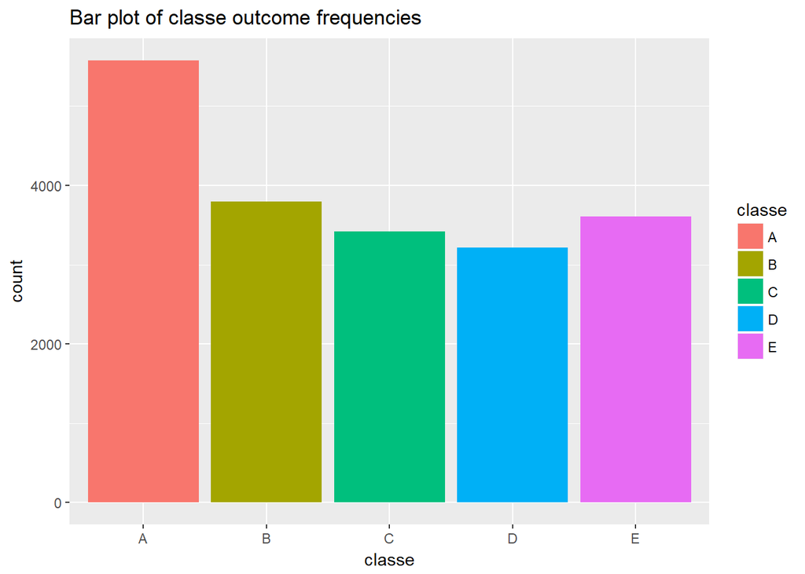

```r
#plot(training$classe, col = "green", main = "Bar Plot of classe outcome frequencies", xlab = "classe", ylab = "count")
qplot(classe, data = training, fill = classe, main = "Bar plot of classe outcome frequencies")
```

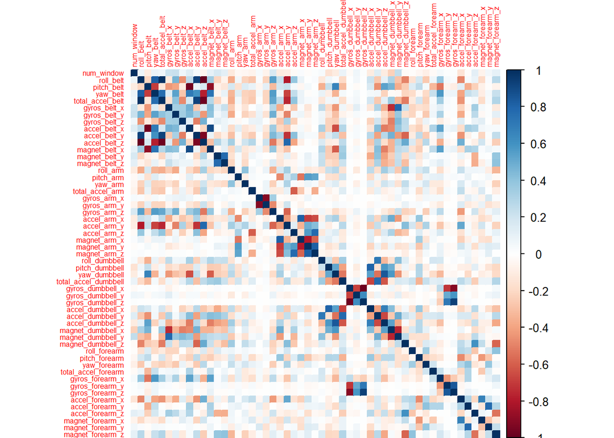

```r
library(corrplot)
corrplot(cor(training[, - length(names(training))]), method = "color", tl.cex = 0.5)
```

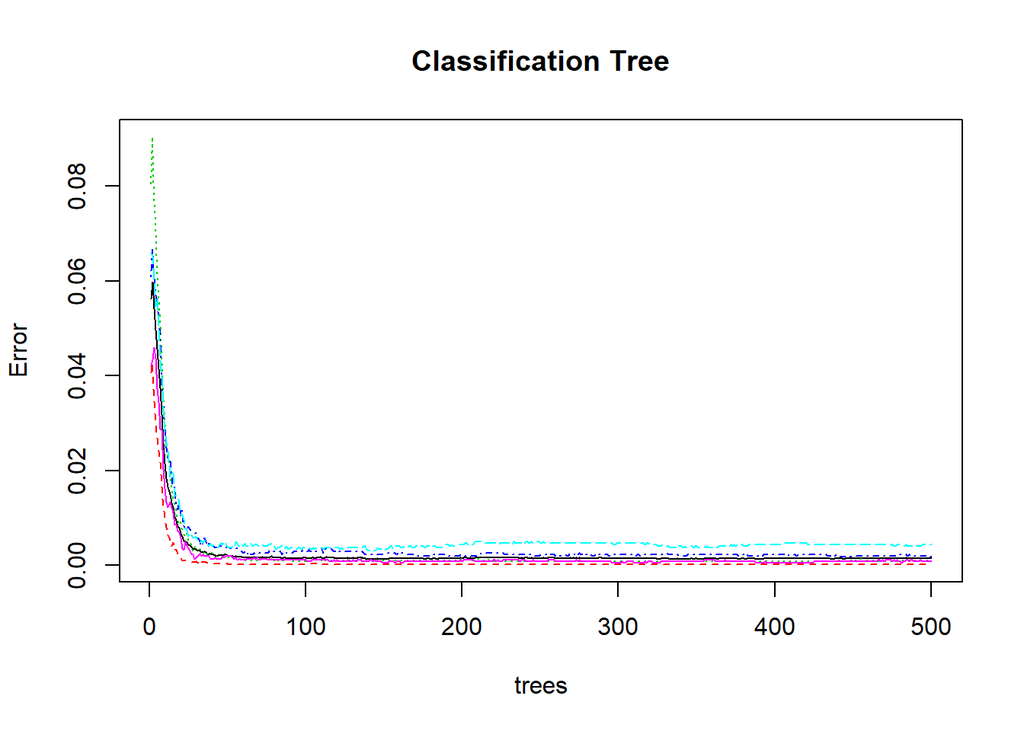

```r
plot(modelRf, uniform = TRUE, main = "Classification Tree") # append $finalModel if train() generated model
```

#### A visualization of the the final model predictors variable importance.

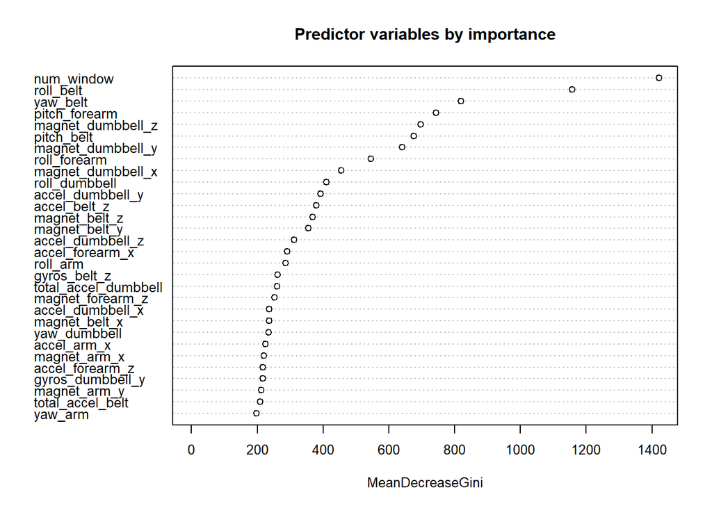

```r
varImpPlot(modelRf, main="Predictor variables by importance", pch = 21, cex=0.8)
```